# ST5227 Midterm Assignment Submission

Yeo Ming Jie, Jonathan

2023-03-08

## Question 1: Forward-Backward Selection

## Question 2: Ridge Regression (Theory)

Consider model

$$Y_i=\beta_1 X_i+\varepsilon_i, \quad i=1, \ldots, n$$

where $X_1, \ldots, X_n$ are non-random values, and $\varepsilon_i, i=1, \ldots, n$ are IID with $E \varepsilon_i=0$ and $\operatorname{Var}\left(\varepsilon_i\right)=\sigma^2$. Let $\mathbf{X}=\left(X_1, \ldots, X_n\right)^{\mathrm{T}}$ and $\mathbf{Y}=\left(Y_1, \ldots, Y_n\right)^{\mathrm{T}}$. We estimate $\beta_1$ by $\operatorname{minimizing}$

$$\left(\mathbf{Y}-\mathbf{X}
\beta_1\right)^{\mathrm{T}}\left(\mathbf{Y}-\mathbf{X}
\beta_1\right)+\lambda \beta_1^2=\sum_{i=1}^n\left\{Y_i-\beta_1
X_i\right\}^2+\lambda \beta_1^2$$
for some $\lambda \geq 0$.

1. Estimator of $\beta_1$ is given by

$$\hat\beta_1(\lambda) = \frac{\sum y_ix_i}{\sum x_i^2 + \lambda}$$

2. Want to derive $Var(\hat\beta_1(\lambda))$. Note that

$$Var(Y_i) = \sigma^2 \Rightarrow Var\left(\sum_{i=1}^n y_ix_i\right) =
\sum_{i=1}^n x_i^2 Var(y_i) = \sigma^2\sum_{i=1}^n x_i^2$$

and hence

$$\begin{aligned}
Var(\hat\beta_1(\lambda)) &= \left\{\sum_{i=1}^n X_i^2 +
\lambda\right\}^{-2} Var\left(\sum_{i=1}^n y_ix_i\right) \\
&= \frac{\sum x_i^2}{ \left\{\sum X_i^2 + \lambda\right\}^2}\sigma^2
\end{aligned}$$

3. Next, note that $Bias(\hat\beta_1(\lambda)) = -\lambda(\sum x_i^2 + \lambda)^{-1}\beta_1$. We want to derive $MSE = E(\hat\beta_1(\lambda) - \beta_1)^2$.

By the Bias-Variance decomposition, we have

$$
$$\begin{aligned}
MSE &= \mathbb{E}\{\hat\beta_1(\lambda) - \beta_1\}^2 \\
&= Var(\hat\beta_1(\lambda)) +
\left\{Bias(\hat\beta_1(\lambda))\right\}^2 \\
&= \sigma^2 \left\{\sum_{i=1}^n X_i^2 + \lambda\right\}^{-2}
\sum_{i=1}^n X_i^2 + \lambda^2 \left\{\sum_{i=1}^n X_i^2 +
\lambda\right\}^{-2} \beta_1^2 \\
&= \frac{\sigma^2\sum x_i^2 + (\lambda \beta_1)^2}{\left\{\sum X_i^2
+ \lambda\right\}^{2}}
\end{aligned}$$

$$

4. Details for choosing $\lambda$ using LOOCV (leave-one-out):

Optimal $\lambda$ st. MSE is minimized. Consider $\lambda \in [0, c]$ for some sufficiently large $c$. For each fixed $\lambda$ in the interval

Compute (where the $j$-th observation is excluded)

$$\hat{\beta}_{\text {ridge }}^j(\lambda)=\left(\sum_{i \neq j} X_i^{\top}
X_i+\lambda I\right)^{-1} \sum_{i \neq j} X_i^{\top} Y_i.$$
Then define the squared difference between actual and prediction as

$$\operatorname{err}^j(\lambda)=\left(Y_j-X_j \hat{\beta}_{\text {ridge
}}^j(\lambda)\right)^2$$

i.e. the prediction error for $\left(X_j, Y_j\right)$.

The, by taking average over prediction errors for all entries (left out) we obtain the cross-validation score

$$C V(\lambda)=n^{-1} \sum_{j=1}^n e r r^j(\lambda)$$

Choose $\lambda$ st. $C V(\lambda)$ is minimized.

5. The effective degrees of freedom is given by

$$\operatorname{df}(\lambda)=\operatorname{trace}\left\{\mathbf{X}\left(\mathbf{X}^{\mathrm{T}}
\mathbf{X}+\lambda\right)^{-1} \mathbf{X}^{\mathrm{T}}\right\}$$
Consider

$$\begin{aligned}
\operatorname{Cov}(\widehat{\mathbf{Y}}(\lambda), \mathbf{Y})) &=
Cov\left(\mathbf{X}\left(\mathbf{X}^{\mathrm{T}}
\mathbf{X}+\lambda\right)^{-1}
\mathbf{X}^{\mathrm{T}}\mathbf{Y},\mathbf{Y} \right) \\
&= \mathbf{X}\left(\mathbf{X}^{\mathrm{T}}
\mathbf{X}+\lambda\right)^{-1}
\mathbf{X}^{\mathrm{T}}\underbrace{Cov(\mathbf{Y},
\mathbf{Y})}_{Var(\mathbf{Y}) = \sigma^2\mathbf{I}}
\end{aligned}$$

Then

$$tr\left(\operatorname{Cov}(\widehat{\mathbf{Y}}(\lambda),
\mathbf{Y}))\right) = \sigma^2
tr\left(\mathbf{X}\left(\mathbf{X}^{\mathrm{T}}
\mathbf{X}+\lambda\right)^{-1} \mathbf{X}^{\mathrm{T}}\right) = \sigma^2
\; df(\lambda)$$

and hence

$$\operatorname{df}(\lambda)=\frac{1}{\sigma^2}
\operatorname{tr}\left(\operatorname{Cov}(\widehat{\mathbf{Y}}(\lambda),
\mathbf{Y})\right)$$

6. Hence

$$\begin{aligned}
\operatorname{df}(0)&=\frac{1}{\sigma^2}
\operatorname{tr}\left(\operatorname{Cov}(\widehat{\mathbf{Y}}(0),
\mathbf{Y})\right) \\
&=\frac{1}{\sigma^2}
tr\left\{\operatorname{Cov}\left(\mathbf{X}\left(\mathbf{X}^{\mathrm{T}}
\mathbf{X}\right)^{-1}
\mathbf{X}^{\mathrm{T}}\mathbf{Y},\mathbf{Y}\right)\right\} \\
&=
\frac{1}{\sigma^2}tr\left\{\mathbf{X}\left(\mathbf{X}^{\mathrm{T}}
\mathbf{X}\right)^{-1}
\mathbf{X}^{\mathrm{T}}\underbrace{Cov(\mathbf{Y},
\mathbf{Y})}_{Var(\mathbf{Y}) = \sigma^2\mathbf{I}}\right\} =
tr\left\{\mathbf{X}^{\mathrm{T}}\mathbf{X}\left(\mathbf{X}^{\mathrm{T}}
\mathbf{X}\right)^{-1} \right\} = tr(1) = 1
\end{aligned}$$

since $\mathbf{X}=\left(X_1, \ldots, X_n\right)^{\mathrm{T}}$ is a vector.

## Question 3

1. For 5 predictors, the two models’ coefficients are given by the columns `s3` and `s4` in `out$beta`, with corresponding lambda values $0.3$ and $0.4$ respectively. Between both models, see that the cross-validation error is minimized where $\lambda = 0.4$.

Hence, estimated model is given by (coefficients from column `s4`)

$$\hat Y = 0.3582V_{2} - 0.1075V_{6} + 0.3535V_{10} - 0.2155V_{14} +
0.4546V_{20}$$

2. Using 5-fold CV to select the model, the cross-validation error is minimized with value $6.935807$ for corresponding lambda value $= 0.4$. From `out$beta`, this corresponds to column `s4`, i.e. the same 5 predictor variables V2, V6, V10, V14 and V20 are selected.

## Question 4

Have the fitted model:

$$\hat{Y_i} = \hat{m}(\mathbf{x}_i) = 1.2 + 1.5\mathbf{x}_i -
0.7\mathbf{x}^2_i + 0.4(\mathbf{x}_i - 0.3)_{+}^3 \quad \text{for} \;\;
i = 1,\dots,100$$

The $95\%$ CI for $E\hat Y$ i.e. prediction interval is

$$E\hat Y \pm 1.96 \Big\{\mathbf{u}^T \hat\Sigma \mathbf{u} \Big\}^{1/2} =
2.1372 \pm 1.96 (0.03844047) = [2.061857, 2.212543]$$

where $\mathbf{u} = (1, x, x^2, (x-0.3)_{+}^3)^T$, $\hat\Sigma = 0.2^2(\mathbb{X}^T\mathbb{X})^{-1}$ and $E\hat Y = m(1.0) = 2.1372$.

## Question 5: Handwritten Digit Recognition

```r
# Note: Digit ID -> 256 grayscale values for each row (one data entry)
zip_train <- read.table('zip.train')
zip_test <- read.table('zip.test')

# Filtering dataset for digit ID = 2 or 3
bin_test <- zip_test[zip_test[,1] == 2 | zip_test[,1] == 3,]
bin_train <- zip_train[zip_train[,1] == 2 | zip_train[,1] == 3,]
```

### (a) Logistic LASSO regression

```r
library(glmnet)
```

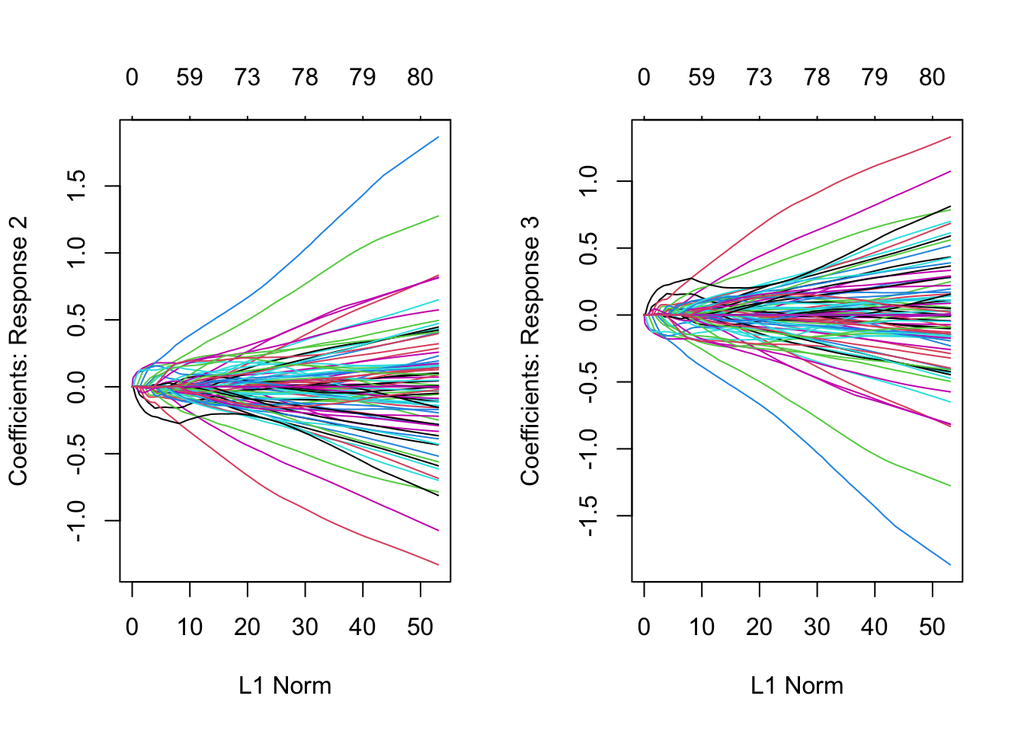

```r
# Training and Test Data
y_train <- as.factor(bin_train[,1]); y_test <- bin_test[,1]
x_train <- as.matrix(bin_train[,2:257]); x_test <- as.matrix(bin_test[,2:257])

# Normalize
x_train <- scale(x_train); x_test <- scale(x_test)

# Fit logistic LASSO (solution path)
fm <- glmnet(x_train, y_train, family = 'multinomial')
par(mfrow = c(1,2)); plot(fm)
```

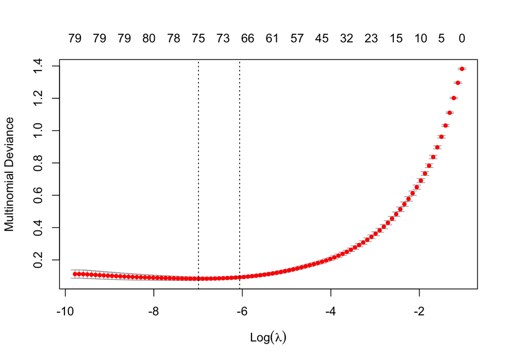

```r
# 5-Fold Cross-Validation for Optimal Lambda tuning parameter
set.seed(5227)
cv <- cv.glmnet(x_train, y_train, family = 'multinomial', nfolds = 5)
lambda = cv$lambda.min
par(mfrow = c(1,1)); plot(cv)
```

```r
# Fit logistic Lasso (Optimal lambda)
fmLasso <- glmnet(x_train, y_train, family = 'multinomial', lambda = lambda)

# To obtain estimates: (uncomment below)
# fmLasso$a0; fmLasso$beta

# Predicted Probabilities and Classes, Misclassification Rate
yProb = predict(fmLasso, newx = x_test, type = "response")
yClass = predict(fmLasso, newx = x_test, type = "class")
classificationError = mean(yClass != y_test)

# Print Outputs (first 5 values)
head(yProb); head(yClass)
```

```
## , , s0
##
##               2            3
## 3  0.0006203305 9.993797e-01
## 12 0.9999992517 7.483160e-07
## 13 0.7861100437 2.138900e-01
## 16 0.0002485065 9.997515e-01
## 21 0.9999999329 6.708571e-08
## 22 0.9999998835 1.165391e-07
```

```
##      s0
## [1,] "3"
## [2,] "2"
## [3,] "2"
## [4,] "3"
## [5,] "2"
## [6,] "2"
```

```r
classificationError
```

```
## [1] 0.0467033
```

### (b) Multilevel Logistic LASSO regression

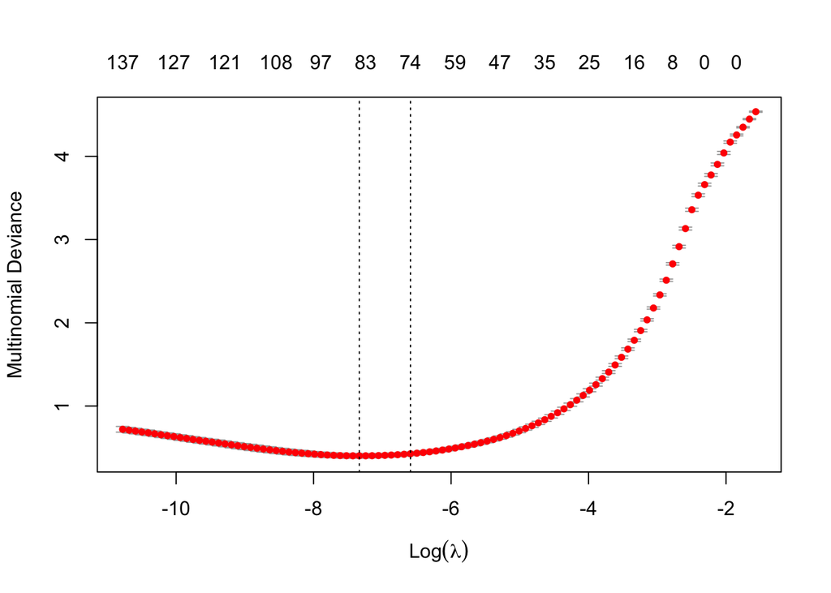

```r
# Training and Test Data
y_train <- as.factor(zip_train[,1]); y_test <- zip_test[,1]
x_train <- as.matrix(zip_train[,2:257]); x_test <- as.matrix(zip_test[,2:257])

# 5-Fold Cross-Validation for Optimal Lambda tuning parameter
set.seed(5227)
cv <- cv.glmnet(x_train, y_train, family = 'multinomial', nfolds = 5)
lambda = cv$lambda.min
par(mfrow = c(1,1)); plot(cv)
```

```r
# LASSO at Optimal Lambda
multi_lasso_est = coef(cv, s = "lambda.min")

# Predicted Probabilities and Classes, Misclassification Rate
yProb = predict(cv, newx = x_test, s = "lambda.min", type = "response")
yClass = predict(cv, newx = x_test, s = "lambda.min", type = "class")
classificationError = mean(yClass != y_test)

# Print Outputs (first 5 values)
round(head(yProb),4); head(yClass)
```

```
## , , 1
##
##           0 1      2      3      4      5      6      7      8      9
## [1,] 0.0000 0 0.0001 0.0003 0.0095 0.0000 0.0000 0.0115 0.0038 0.9749
## [2,] 0.0013 0 0.0128 0.0000 0.0003 0.0079 0.9777 0.0000 0.0000 0.0000
## [3,] 0.0000 0 0.0019 0.9969 0.0000 0.0000 0.0000 0.0000 0.0012 0.0000
## [4,] 0.3658 0 0.0401 0.0000 0.0008 0.0483 0.5440 0.0009 0.0000 0.0000
## [5,] 0.0029 0 0.0060 0.0000 0.0000 0.0016 0.9895 0.0000 0.0000 0.0000
## [6,] 0.9995 0 0.0001 0.0000 0.0000 0.0000 0.0004 0.0000 0.0001 0.0000
```

```
##      1
## [1,] "9"
## [2,] "6"
## [3,] "3"
## [4,] "6"
## [5,] "6"
## [6,] "0"
```

```r
classificationError
```

```
## [1] 0.08669656
```